```python
__nbid__ = '0009'
__author__ = 'David Nidever <david.nidever@noirlab.edu>, Knut Olsen <knut.olsen@noirlab.edu>, Robert Nikutta <robert.nikutta@noirlab.edu>, Stephanie Juneau <stephanie.juneau@noirlab.edu>'
__version__ = '20240603' # yyyymmdd
__datasets__ = ['nsc_dr2']
__keywords__ = ['science example', 'dwarf galaxies']
```

# Detecting dwarf galaxies in NSC DR2

*David Nidever, Knut Olsen, Robert Nikutta, Stéphanie Juneau, & Astro Data Lab Team*

- Goals & notebook summary
- Disclaimer & attribution
- Imports & setup
- Preface
- Chapter 1 - Photometry containing dwarfs
- Chapter 2 - Filtering and plotting the dwarfs
- Chapter 3 - Retrieve Images
- Resources

# Goals

In this notebook, we demonstrate the discovery of classical and faint Milky Way dwarf companions in NSC DR2. We query the database around the positions of known dwarfs and apply filtering techniques to reveal the dwarfs as spatial overdensities of filtered sources.

# Summary

**Background** Ultrafaint dwarf galaxies are crucial to understanding many aspects of the universe. For instance, they are dominated by dark matter; their localization in space can thus trace the large-scale structure of the dark matter distribution.

**Data retrieval** We will retrieve data from the NSC DR2 catalog ([Nidever et al. 2020](https://arxiv.org/abs/2011.08868)) and look for overdensities of blue objects.

The required columns are RA, Dec, and the g, r, i magnitudes.

**Detection** We will convolve the spatial distribution of our dataset with a pair of Gaussian kernels and subtract the results, as done in e.g. [Stanford et al. (2005, ApJ, 634, 2, L129)](http://adsabs.harvard.edu/abs/2005ApJ...634L.129S) (galaxy clusters), or [Koposov et al. (2008, ApJ, 686, 279)](http://adsabs.harvard.edu/abs/2008ApJ...686..279K) (MW satellites). This has the effect of convolving the spatial distribution with a Mexican hat filter, which is useful for detecting objects at a desired spatial scale.

# Disclaimer & attribution

## Disclaimers

Note that using the Astro Data Lab constitutes your agreement with our minimal [Disclaimers](https://datalab.noirlab.edu/disclaimers.php).

## Acknowledgments

If you use **Astro Data Lab** in your published research, please include the text in your paper's Acknowledgments section:

*This research uses services or data provided by the Astro Data Lab, which is part of the Community Science and Data Center (CSDC) Program of NSF NOIRLab. NOIRLab is operated by the Association of Universities for Research in Astronomy (AURA), Inc. under a cooperative agreement with the U.S. National Science Foundation.*

If you use **SPARCL jointly with the Astro Data Lab platform** (via JupyterLab, command-line, or web interface) in your published research, please include this text below in your paper's Acknowledgments section:

*This research uses services or data provided by the SPectra Analysis and Retrievable Catalog Lab (SPARCL) and the Astro Data Lab, which are both part of the Community Science and Data Center (CSDC) Program of NSF NOIRLab. NOIRLab is operated by the Association of Universities for Research in Astronomy (AURA), Inc. under a cooperative agreement with the U.S. National Science Foundation.*

In either case **please cite the following papers**:

- Data Lab concept paper: Fitzpatrick et al., "The NOAO Data Laboratory: a conceptual overview", SPIE, 9149, 2014, https://doi.org/10.1117/12.2057445
- Astro Data Lab overview: Nikutta et al., "Data Lab - A Community Science Platform", Astronomy and Computing, 33, 2020, https://doi.org/10.1016/j.ascom.2020.100411

If you are referring to the Data Lab JupyterLab / Jupyter Notebooks, cite:

- Juneau et al., "Jupyter-Enabled Astrophysical Analysis Using Data-Proximate Computing Platforms", CiSE, 23, 15, 2021, https://doi.org/10.1109/MCSE.2021.3057097

If publishing in a AAS journal, also add the keyword: `\facility{Astro Data Lab}`

And if you are using SPARCL, please also add `\software{SPARCL}` and cite:

- Juneau et al., "SPARCL: SPectra Analysis and Retrievable Catalog Lab", Conference Proceedings for ADASS XXXIII, 2024 https://doi.org/10.48550/arXiv.2401.05576

The NOIRLab Library maintains [lists of proper acknowledgments](https://noirlab.edu/science/about/scientific-acknowledgments) to use when publishing papers using the Lab's facilities, data, or services.

# Imports and setup

```python
# std lib
from getpass import getpass

# 3rd party
import pandas as pd
import numpy as np
import pylab as plt
import matplotlib
from astropy import utils, io, convolution, stats, wcs
from astropy.visualization import make_lupton_rgb
from astropy import units as u
from astropy.stats import median_absolute_deviation as mad
from astropy.coordinates import name_resolve
%matplotlib inline

# Data Lab
from dl import authClient as ac, queryClient as qc, storeClient as sc, helpers

#Simple Image Access (SIA) service
from pyvo.dal import sia
DEF_ACCESS_URL = "https://datalab.noirlab.edu/sia"
svc = sia.SIAService(DEF_ACCESS_URL)

# Quiet the Astropy warnings
import warnings
from astropy.utils.exceptions import AstropyWarning
warnings.simplefilter('ignore', category=AstropyWarning)
```

# Preface

We're going to select the database and define some functions that we'll use later.

```python
#The NSC DR1 schema
try:
    print(qc.schema('nsc_dr2', format='json', profile='default'))
except Exception as e:
    print(e.message)
```

```
Schema: nsc_dr2

      Table Name   Description
      ----------   -----------
            chip   CCD information table
        coverage   Survey coverage table
        exposure   Exposures contributing to the catalog
            meas   Primary measurements table
          object   Primary object table
x1p5__object__allwise__source   nsc_dr2.object and allwise.source crossmatch (1.5 arcsec)
x1p5__object__catwise2020__main   xmatch_std.nsc_dr2__object and catwise2020.main crossmatch
                   (1.5 arcsec)
x1p5__object__decaps_dr1__object   nsc_dr2.object and decaps_dr1.object crossmatch (1.5 arcsec)
x1p5__object__decaps_dr2__object   xmatch_std.nsc_dr2__object and decaps_dr2.object crossmatc
                   h (1.5 arcsec)
x1p5__object__delve_dr1__objects   nsc_dr2.object and delve_dr1.objects crossmatch (1.5 arcsec)
x1p5__object__delve_dr2__objects   xmatch_std.nsc_dr2__object and delve_dr2.objects crossmatc
                   h (1.5 arcsec)
x1p5__object__des_dr1__main   nsc_dr2.object and des_dr1.main crossmatch (1.5 arcsec)
x1p5__object__des_dr2__main   nsc_dr2.object and des_dr2.main crossmatch (1.5 arcsec)
x1p5__object__desi_edr__zpix   xmatch_std.nsc_dr2__object and desi_edr.zpix crossmatch (1
                   .5 arcsec)
x1p5__object__gaia_dr1__gaia_source   nsc_dr2.object and gaia_dr1.gaia_source crossmatch (1.5 arcsec)
x1p5__object__gaia_dr2__gaia_source   nsc_dr2.object and gaia_dr2.gaia_source crossmatch (1.5 arcsec)
x1p5__object__gaia_dr3__gaia_source   xmatch_std.nsc_dr2__object and gaia_dr3.gaia_source crossm
                   atch (1.5 arcsec)
x1p5__object__gnirs_dqs__spec_measurements   xmatch_std.nsc_dr2__object and gnirs_dqs.spec_measurements
                   crossmatch (1.5 arcsec)
x1p5__object__gogreen_dr1__photo   nsc_dr2.object and gogreen_dr1.photo crossmatch (1.5 arcsec)
x1p5__object__gogreen_dr1__redshift   nsc_dr2.object and gogreen_dr1.redshift crossmatch (1.5 arcsec)
x1p5__object__ls_dr10__tractor   xmatch_std.nsc_dr2__object and ls_dr10.tractor crossmatch
                   (1.5 arcsec)
x1p5__object__ls_dr8__tractor   xmatch_std.nsc_dr2__object and ls_dr8.tractor crossmatch (
                   1.5 arcsec)
x1p5__object__ls_dr9__tractor   xmatch_std.nsc_dr2__object and xmatch_std.ls_dr9__tractor
                   crossmatch (1.5 arcsec)
x1p5__object__sdss_dr12__specobj   nsc_dr2.object and sdss_dr12.specobj crossmatch (1.5 arcsec)
x1p5__object__sdss_dr13__specobj   nsc_dr2.object and sdss_dr13.specobj crossmatch (1.5 arcsec)
x1p5__object__sdss_dr14__specobj   nsc_dr2.object and sdss_dr14.specobj crossmatch (1.5 arcsec)
x1p5__object__sdss_dr16__specobj   nsc_dr2.object and sdss_dr16.specobj crossmatch (1.5 arcsec)
```

[output cut: 16 more lines]

```
x1p5__object__twomass__xsc   nsc_dr2.object and twomass.xsc crossmatch (1.5 arcsec)
x1p5__object__ukidss_dr11plus__dxssource   xmatch_std.nsc_dr2__object and ukidss_dr11plus.dxssource c
                   rossmatch (1.5 arcsec)
x1p5__object__ukidss_dr11plus__gcssource   xmatch_std.nsc_dr2__object and ukidss_dr11plus.gcssource c
                   rossmatch (1.5 arcsec)
x1p5__object__ukidss_dr11plus__gpssource   xmatch_std.nsc_dr2__object and ukidss_dr11plus.gpssource c
                   rossmatch (1.5 arcsec)
x1p5__object__ukidss_dr11plus__lassource   xmatch_std.nsc_dr2__object and ukidss_dr11plus.lassource c
                   rossmatch (1.5 arcsec)
x1p5__object__ukidss_dr11plus__udssource   xmatch_std.nsc_dr2__object and ukidss_dr11plus.udssource c
                   rossmatch (1.5 arcsec)
x1p5__object__unwise_dr1__object   nsc_dr2.object and unwise_dr1.object crossmatch (1.5 arcsec)
x1p5__object__usno__a2   nsc_dr2.object and usno.a2 crossmatch (1.5 arcsec)
x1p5__object__usno__b1   nsc_dr2.object and usno.b1 crossmatch (1.5 arcsec)
x1p5__object__vhs_dr5__vhs_cat_v3   nsc_dr2.object and vhs_dr5.vhs_cat_v3 crossmatch (1.5 arcsec)
```

```python
# A function to retrieve data from a point on the sky
def getData (ra,dec,radius=1.0,columns='*'):

    query_template = \
    """SELECT {0:s} FROM nsc_dr2.object
       WHERE q3c_radial_query(ra,dec,{1:f},{2:f},{3:f})"""

    query = query_template.format(columns,ra,dec,radius)
    print(query)

    try:
        result = qc.query(sql=query) # by default the result is a CSV formatted string
    except Exception as e:
        print(e.message)

    df = helpers.utils.convert(result,'pandas')

    return df
```

```python
# A Mexican-hat convolution filter
def dwarf_filter (ra,dec,fwhm_small=2.0,fwhm_big=20):

    # Based on Koposov et al. (2008).
    # Code by Ken Mighell and Mike Fitzpatrick.
    # Minor edits by Rorbert Nikutta.

    x, y = ra, dec

    # Information about declination (y) [degrees]
    ymean = (y.min() + y.max()) / 2.0
    ydiff_arcmin = (y.max() - y.min()) * 60.0 # convert from degrees to arcmin

    # Information about right ascension (x) [degrees in time]:
    xdiff = x.max() - x.min() # angular separation [degrees (time)]
    xmean = (x.min() + x.max())/2.0

    # convert from degrees in time to separation in angular degrees:
    xdiff_angular = (x.max() - x.min()) * np.cos(ymean*(np.pi/180.0))

    # convert from degress to arcmin
    xdiff_angular_arcmin = xdiff_angular * 60.0

    # Get the number of one-arcmin pixels in the X and Y directions:
    nx = np.rint (xdiff_angular_arcmin).astype('int')
    ny = np.rint (ydiff_arcmin).astype('int')

    # Create a two-dimensional histogram of the raw counts:
    Counts, xedges, yedges  = np.histogram2d (x, y, (nx,ny) )
    extent = [xedges[0], xedges[-1], yedges[0], yedges[-1]]
    raw_hist = np.rot90(Counts).copy() # hack around Pythonic weirdness

    # Make the small and big Gaussian kernels with a standard deviation
    # of the given FWHM in arcmin^2 pixels.
    kernel_small = convolution.Gaussian2DKernel(fwhm_small/2.35,factor=1)
    kernel_big = convolution.Gaussian2DKernel(fwhm_big/2.35,factor=1)

    # Compute the differential convolution kernels.
    conv_big = convolution.convolve (raw_hist, kernel_big)
    conv_small = convolution.convolve (raw_hist, kernel_small)
    conv_delta = conv_small - conv_big
    delta = conv_delta.copy()

    # Compute statistics and the floor
    mean = np.mean (delta, dtype='float64')
    sigma = np.std (delta, dtype='float64')
    sigmaRaw = np.std(raw_hist,dtype='float64')
    median = np.median (delta)                       # not used
    floor = mean

    # Clip to specified limits.
    clipped = delta.copy()
    clipped[ delta < floor ] = floor

    # Return the computed fields.
    return raw_hist, extent, delta, clipped, sigma
```

```python
# A little function to download the deepest stacked images
#   adapted from R. Nikutta
def download_deepest_image(ra,dec,fov=0.1,band='g'):
    imgTable = svc.search((ra,dec), (fov/np.cos(dec*np.pi/180), fov), verbosity=2).to_table()
    print("The full image list contains", len(imgTable), "entries")

    sel0 = imgTable['obs_bandpass'] == band
    sel = sel0 & ((imgTable['proctype'] == 'Stack') & (imgTable['prodtype'] == 'image')) # basic selection
    Table = imgTable[sel] # select
    if (len(Table)>0):
        row = Table[np.argmax(Table['exptime'].data.data.astype('float'))] # pick image with longest exposure time
        url = row['access_url'] # get the download URL
        print ('downloading deepest image...')
        image = io.fits.getdata(utils.data.download_file(url,cache=True,show_progress=False,timeout=120))

    else:
        print ('No image available.')
        image=None

    return image
```

```python
# Multi panel image plotter
def plot_images(images,geo=None,panelsize=4,bands=list('gri'),cmap=matplotlib.cm.gray_r):
    n = len(images)
    if geo is None: geo = (n,1)

    fig = plt.figure(figsize=(geo[0]*panelsize,geo[1]*panelsize))
    for j,img in enumerate(images):
        ax = fig.add_subplot(geo[1],geo[0],j+1)
        if img is not None:
            print(img.min(),img.max())
            vmin = np.median(img)-2*np.std(img)
            vmax = np.median(img)+2*np.std(img)
            ax.imshow(img,origin='lower',interpolation='none',cmap=cmap,norm=matplotlib.colors.LogNorm(vmin=vmin, vmax=vmax))
            ax.set_title('%s band' % bands[j])
            ax.xaxis.set_visible(False)
            ax.yaxis.set_visible(False)
```

# Chapter 1 - Photometry containing dwarfs

We take the positions of four dwarf galaxies and query the database around them.

```python
# Locations of Dwarfs from McConnachie et al. (2012), Bechtol et al. (2015) and others
name = ['Draco Dsph','Carina Dsph','Hya II','Eri II']

# hard-coded coordinates; can also resolve them dynamically (see further below)
ra = [260.059728, 100.40292, 185.42542, 56.0878]
dec = [57.921219, -50.96611, -31.98528, -43.5332]

radius = 0.85 # search radius in degrees

# ask the database for these columns
columns = '''ra,dec,gmag,gerr,imag,rmag,zmag,class_star,fwhm'''
```

```python
def resolve_coordinates(name):
    try:
        coords = name_resolve.get_icrs_coordinates(name)
    except Exception as e:
        raise

    ra = coords.ra.to('deg').value
    dec = coords.dec.to('deg').value

    return coords, ra, dec
```

```python
# collect query results in this dictionary
df_dict = {dwarf: pd.DataFrame() for dwarf in name}

# loop over the dwarfs
for j,name_ in enumerate(name):
    print(name_)
#uncomment-me    coords, ra_, dec_ = resolve_coordinates(name_)  # resolve coordinates dynamically
    coords, ra_, dec_ = None, ra[j], dec[j]  # use hard-coded coordinates
    df = getData(ra_,dec_,radius=radius,columns=columns)
    df_dict[name_] = df
    print(str(len(df))+' objects found')
```

```
Draco Dsph
SELECT ra,dec,gmag,gerr,imag,rmag,zmag,class_star,fwhm FROM nsc_dr2.object
       WHERE q3c_radial_query(ra,dec,260.059728,57.921219,0.850000)
90835 objects found
Carina Dsph
SELECT ra,dec,gmag,gerr,imag,rmag,zmag,class_star,fwhm FROM nsc_dr2.object
       WHERE q3c_radial_query(ra,dec,100.402920,-50.966110,0.850000)
614912 objects found
Hya II
SELECT ra,dec,gmag,gerr,imag,rmag,zmag,class_star,fwhm FROM nsc_dr2.object
       WHERE q3c_radial_query(ra,dec,185.425420,-31.985280,0.850000)
280984 objects found
Eri II
SELECT ra,dec,gmag,gerr,imag,rmag,zmag,class_star,fwhm FROM nsc_dr2.object
       WHERE q3c_radial_query(ra,dec,56.087800,-43.533200,0.850000)
162625 objects found
```

# Chapter 2 - Filtering and plotting the dwarfs

```python
# Create a WCS for a tangent plane projection in our region
def get_wcs(ra,dec,image,fov=1.,unit='deg',projection=("RA---TAN","DEC--TAN")):
    npix = image.shape[0]
    crpix = npix/2 + 1
    cdelt = fov/float(npix)
    w = wcs.WCS(naxis=2)
    w.wcs.cunit = (unit,unit)
    w.wcs.crpix = (crpix,crpix)
    w.wcs.cdelt = np.array((-cdelt,cdelt))
    w.wcs.ctype = projection
    w.wcs.crval = (ra,dec) #coords.ra.to(unit).value, coords.dec.to(unit).value)
    return w
```

```
Draco Dsph
Carina Dsph
Hya II
Eri II
```

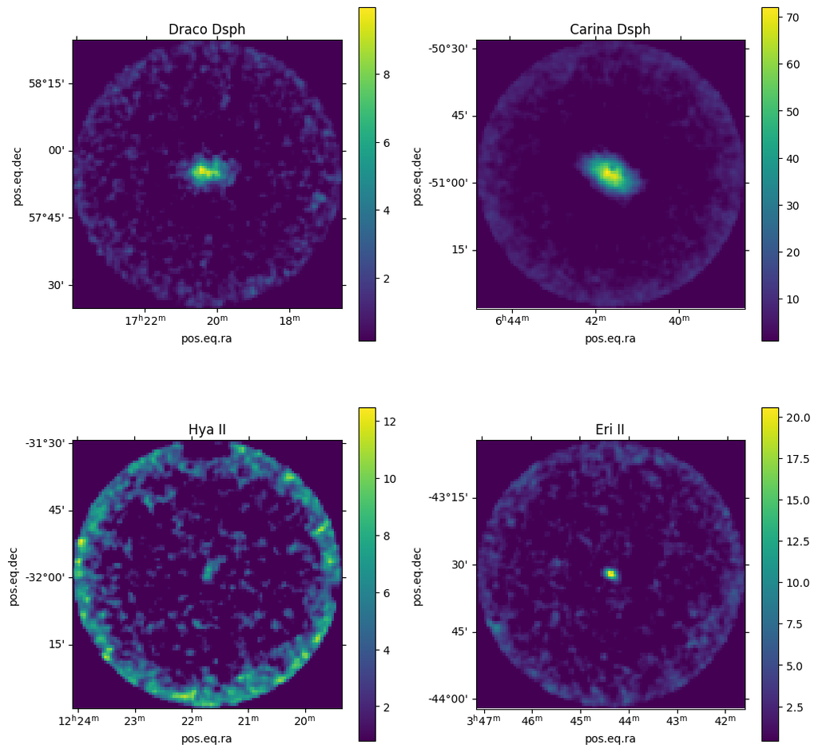

```python
# Loop over the dwarfs, filter then and plot a density map
nrow, ncol = 2, 2
fig = plt.figure(figsize=(6*ncol,6*nrow))
for j,name_ in enumerate(df_dict):
    print(name_)
    df = df_dict[name_]
    keep = (df['gmag']<90) & (df['rmag']<90) & \
           1.087/df['gerr']>10 & \
           ((df['gmag']-df['rmag'])<1.0) & (df['gmag']>18) & ((df['gmag']-df['rmag'])>(-0.5)) & \
           (np.abs(df['class_star'])>0.8) & (df['fwhm']<2)
    df2 = df[keep]
    raw_hist, extent, delta, clipped, sigma = dwarf_filter(df2['ra'],df2['dec'])
    #skyPlot(df2,ax)
    w = get_wcs(ra[j],dec[j],clipped,fov=1.)
    ax = fig.add_subplot(nrow,ncol,j+1,projection=w)
    im = plt.imshow(clipped)
    plt.colorbar()
    ax.set_title(name_)
```

# Chapter 3 - Retrieve images

We demonstrate how to retrieve images though the SIA (Simple Image Access) service.

```python
# Get g, r and i stacked image for the third galaxy
rac = ra[2]
decc = dec[2]
band = 'g'
gimage = download_deepest_image(rac, decc, fov=0.1, band=band) # FOV in deg
band = 'r'
rimage = download_deepest_image(rac, decc, fov=0.1, band=band) # FOV in deg
band = 'i'
iimage = download_deepest_image(rac, decc, fov=0.1, band=band) # FOV in deg
images=[gimage,rimage,iimage]
```

```
The full image list contains 3277 entries
downloading deepest image...
The full image list contains 3277 entries
downloading deepest image...
The full image list contains 3277 entries
downloading deepest image...
```

```
2304.0452 39016.523
3063.2227 39893.363
2365.7983 39021.27
```

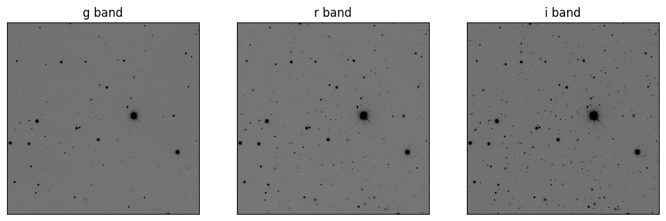

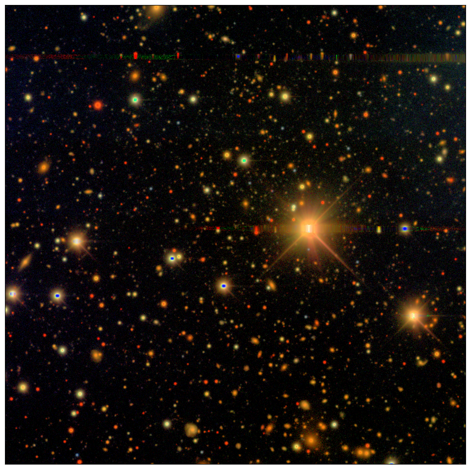

```python
# Now plot the image per band and a 3-color image
gimage2 = gimage-np.median(gimage)
rimage2 = rimage-np.median(rimage)
iimage2 = iimage-np.median(iimage)
img = make_lupton_rgb(iimage2, rimage2, gimage2, Q=10, stretch=30)
plot_images(images)

fig = plt.figure(figsize=[12,12])
ax = fig.add_subplot(1,1,1)

ax.imshow(img,origin='lower')
ax.xaxis.set_visible(False)
ax.yaxis.set_visible(False)
```

## Resources and references

Nidever et al. (2020) "Second Data Release of the All-sky NOIRLab Source Catalog", AJ, https://arxiv.org/abs/2011.08868

Nidever et al. (2018) "First Data Release of the All-sky NOAO Source Catalog": http://adsabs.harvard.edu/abs/2018AJ....156..131N

McConnachie et al. (2012, AJ, 144, 4) "The Observed Properties of Dwarf Galaxies in and around the Local Group": http://adsabs.harvard.edu/abs/2012AJ....144....4M

Bechtol, K., et al. (2015, ApJ, 807, 50) "Eight New Milky Way Companions Discovered in First-year Dark Energy Survey Data": http://adsabs.harvard.edu/abs/2015ApJ...807...50B

Koposov et al. (2008, ApJ, 686, 279) "The Luminosity Function of the Milky Way Satellites": http://adsabs.harvard.edu/abs/2008ApJ...686..279K